# Build gene co-expression network (GCN) from time-course gene expression data

# (WGCNA) Format data

- transpose the dataset: rows = timepoints, cols = genes

```r
datExpr <- dat_sub_unique %>%
  transpose_data()
```

## QC

```r
datExpr %>%
  check_sample_quality()
```

```
 Flagging genes and samples with too many missing values...
  ..step 1
All okay!
```

```
Visualizing the log-transformed data
```

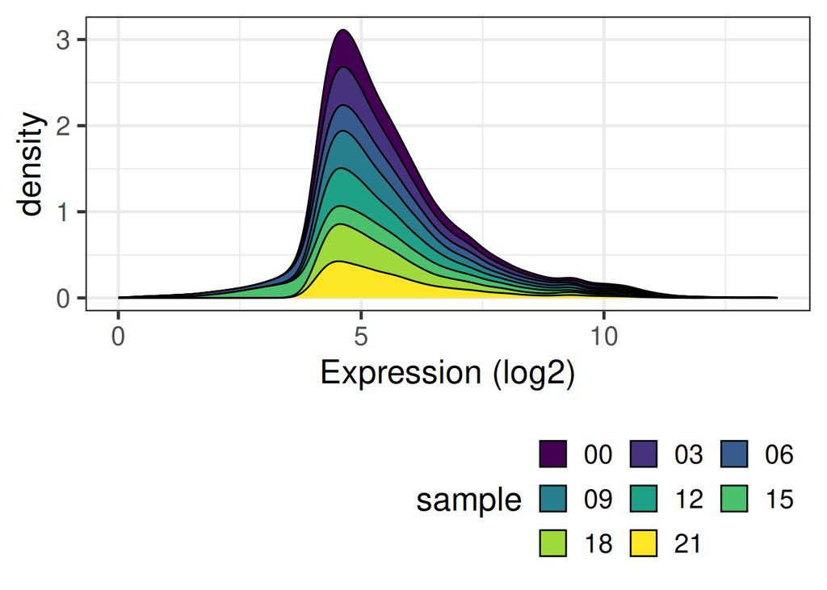

```r
datExpr %>%
  plot_sample_expression()
```

# Calculate gene-gene similarity

```r
# Calculate Kendall's tau-b correlation for each gene-gene pair
sim_matrix <- calculate_gene_gene_sim(
  data = datExpr,
  name = which.sample,
  cache = FALSE
)
```

```
Running gene-gene similarity...Done.
```

## QC

```r
cat("Before power transformation:")
```

```
Before power transformation:
```

```
Plotting a chunk of the gene-gene similarity matrix with 200 genes.
```

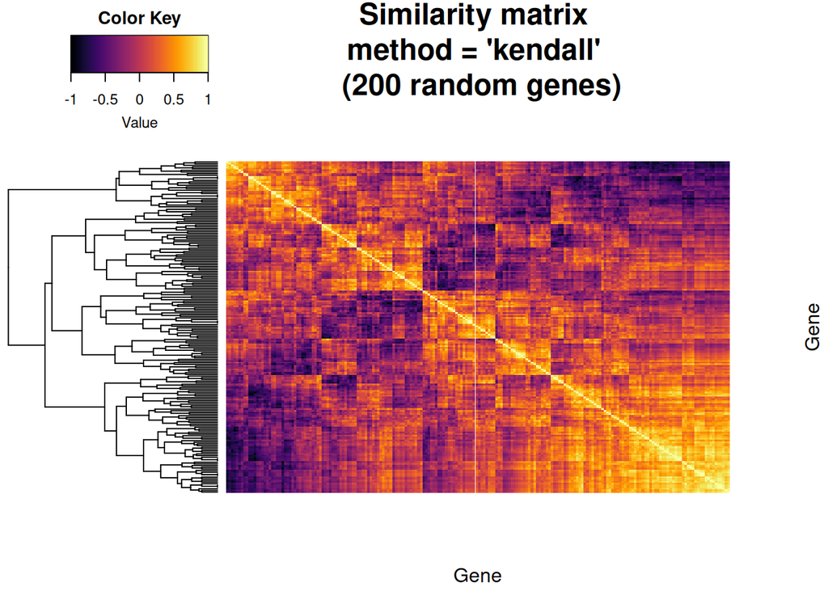

```r
plot_sim_matrix(
  matrix = sim_matrix
)
```

# Create adjacency matrix

## USER INPUT REQUIRED —-

To create the adjacency matrix, we need to first identify the soft-thresholding power (see WGCNA for more info).

```
Performing network topology analysis to pick
  soft-thresholding power...
   Power SFT.R.sq    slope truncated.R.sq mean.k. median.k. max.k.
1      1 0.968000  2.93000          0.959    1650      1730   2060
2      2 0.951000  1.24000          0.937    1120      1180   1620
3      3 0.918000  0.65200          0.896     851       879   1360
4      4 0.878000  0.33300          0.849     683       691   1190
5      5 0.650000  0.13500          0.578     569       572   1060
6      6 0.000434 -0.00168         -0.237     486       483    966
7      7 0.638000 -0.10600          0.549     422       416    887
8      8 0.775000 -0.19400          0.710     373       364    822
9      9 0.851000 -0.26000          0.808     333       322    766
10    10 0.879000 -0.30900          0.846     300       287    718
11    12 0.882000 -0.39800          0.852     248       230    638
12    15 0.886000 -0.49000          0.870     195       171    550
13    18 0.886000 -0.56000          0.888     159       134    483
14    21 0.883000 -0.62100          0.892     133       106    431

Plotting resutls from the network topology analysis...
```

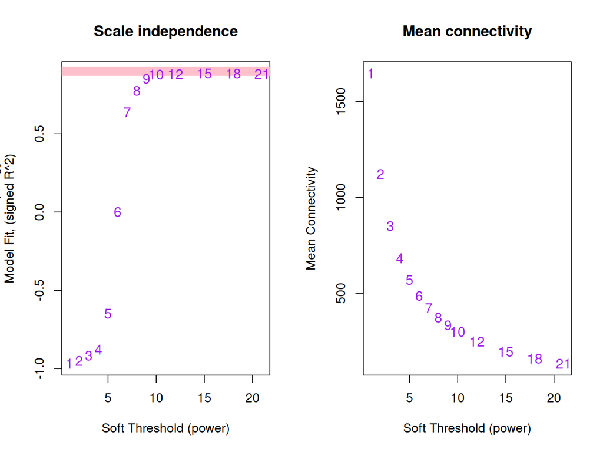

```
Done.
[ NOTE, FIGURE ]: Red horizontal line indicates a signed R^2 of 0.9
```

```r
sft <- analyze_network_topology(
  data = datExpr
)
```

```r
my_estimate <- sft$fitIndices |>
  filter(
    SFT.R.sq > 0.8 &
      SFT.R.sq <= 0.9,
    Power > 6 &
      Power < 14
  ) |>
  arrange(
    Power
  ) |>
  head(1) |>
  pull(1)
```

Now, we can go ahead and create our adjacency matrix by power-transforming the similarity matrix (see WGCNA for more info).

```r
## Specify the soft-thresholding-power
soft.power = if_else(
  sft$powerEstimate < 16,
  max(sft$powerEstimate, my_estimate),
  my_estimate
)

cat("Selected soft-power:", soft.power)
```

```
Selected soft-power: 9
```

```r
# Construct adjacency matrix
# TO DO: make function ----
adj_matrix <- WGCNA::adjacency.fromSimilarity(
  sim_matrix,
  power = soft.power,
  type = "signed"
) |>
  as.matrix()

cat("After power transformation:")
```

```
After power transformation:
```

```
Plotting a chunk of the gene-gene similarity matrix with 200 genes.
```

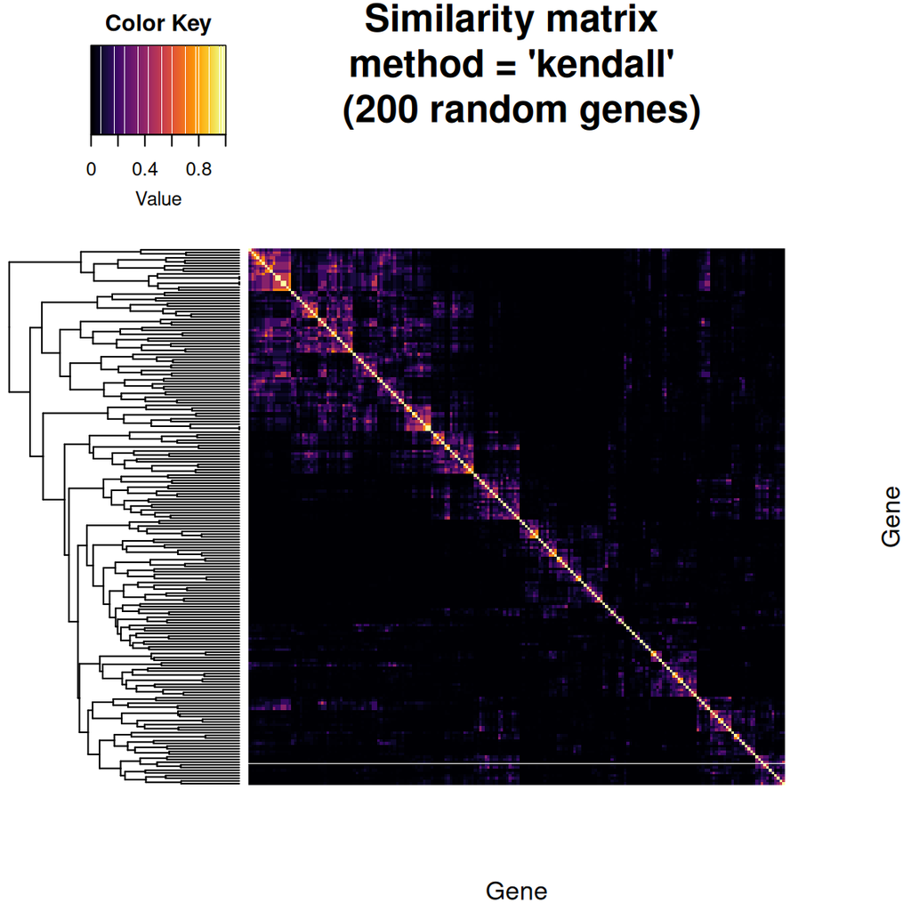

```r
plot_sim_matrix(
  matrix = adj_matrix
)
```

# Identify gene clusters

The following steps are performed as per guidelines from the WGCNA package and several tutorials made available online.

### 2.1 Create topological overalp matrix

```r
# Turn adjacency into topological overlap
dissTOM = 1 - WGCNA::TOMsimilarity(adj_matrix)
```

```
..connectivity..
..matrix multiplication (system BLAS)..
..normalization..
..done.
```

```r
# Call the hierarchical clustering function
geneTree = perform_hclust(
  data = dissTOM
)
```

### 2.2 Identify clusters

User defined parameters:

- minimum size (number of genes) of modules

> We like large modules, so we set the minimum module size relatively high (50).

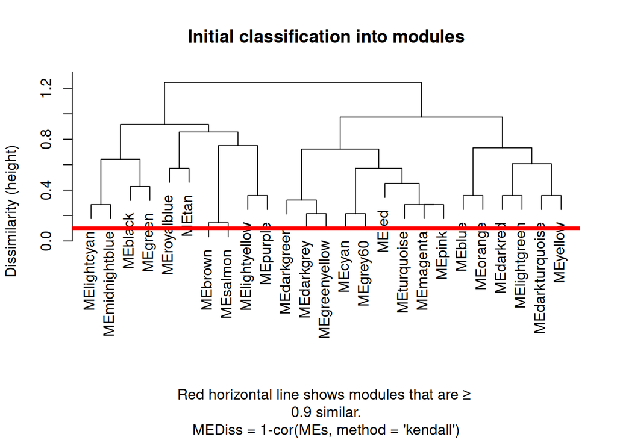

```
Merging modules that have a correlation ≥ 0.9 ...Done.
[ NOTE, FIGURE ] Plotting identified clusters before and after merging.
```

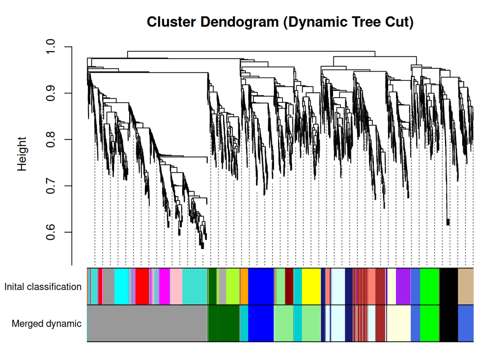

```
Module (cluster) size:
mergedColors
        black          blue         brown     darkgreen darkturquoise
          150           210           185           260           130
        green        grey60     lightcyan    lightgreen   lightyellow
          155           990           238           314           213
 midnightblue     royalblue
          118           198
```

```r
minModuleSize = 50
# Module identification using dynamic tree cut:
modules <- create_modules(
  tree = geneTree,
  dissTOM = dissTOM,
  data = datExpr,
  min_module_size = minModuleSize
)
```

### 2.3 Merge similar modules

User defined parameters:

- minimum correlation between two modules above which they are merged into one | var-name: MEDissThres

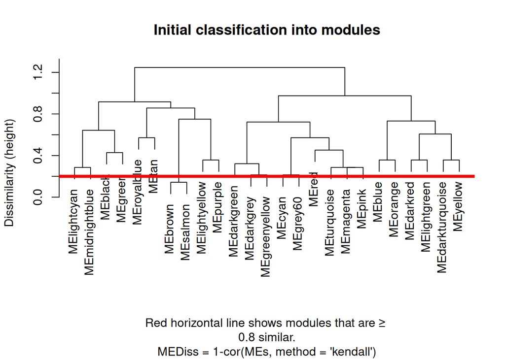

```
Merging modules that have a correlation ≥ 0.8 ...Done.
[ NOTE, FIGURE ] Plotting identified clusters before and after merging.
```

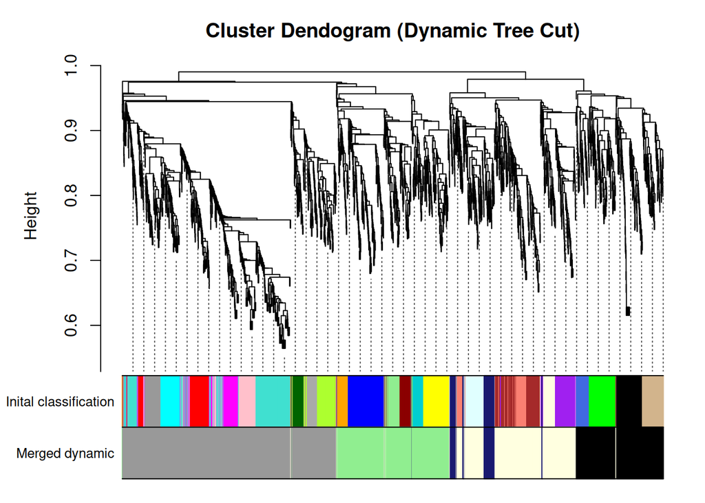

```
Module (cluster) size:
mergedColors
       black       grey60   lightgreen  lightyellow midnightblue
         503         1250          654          636          118
```

```r
cutoff <- 0.8

merge = create_modules(
  tree = geneTree,
  dissTOM = dissTOM,
  min_module_size = minModuleSize,
  merge_cutoff_similarity = 0.8, # 70 % similarity
  data = datExpr
)
```

```r
n_modules <- ncol(merge$modules$newMEs)

while (n_modules > 15) {
  cutoff <- cutoff - 0.05
  merge <- create_modules(
    tree = geneTree,
    dissTOM = dissTOM,
    min_module_size = minModuleSize,
    merge_cutoff_similarity = cutoff, # 70 % similarity
    data = datExpr
  )
  n_modules <- ncol(merge$modules$newMEs)
}

cat("Cutoff:", cutoff)
```

```
Cutoff: 0.8
```

```r
cat("Number of modules:", n_modules)
```

```
Number of modules: 5
```

### 2.4 Calculate module-module similarity

```
Calculating module-module similarity based
  on module-eigengene-expression...Done.
Tidying module names...Done.
Plotting adjacency matrix for module-module similarity...
```

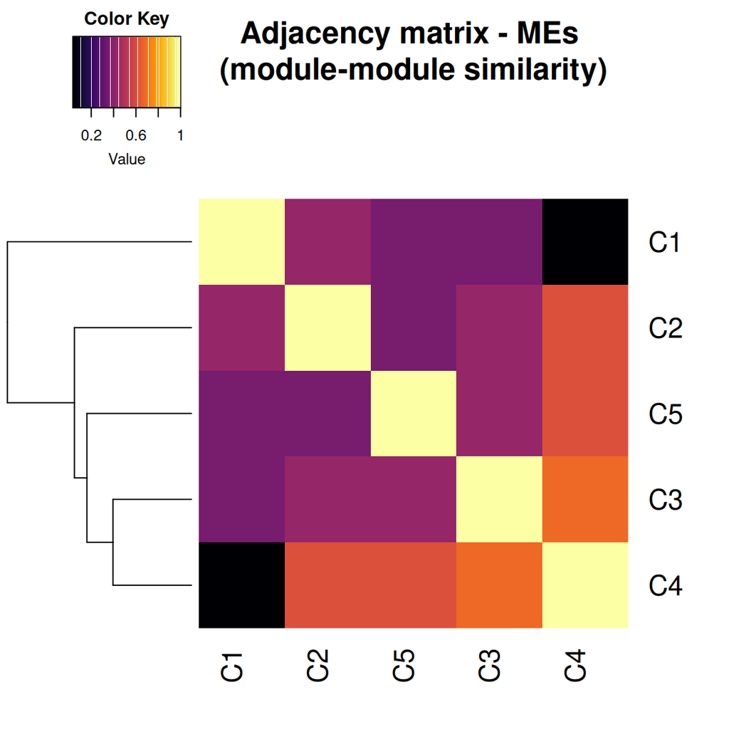

```
Done.
```

```r
adj_matrix_ME <- calculate_module_module_sim(
  merged_modules = merge[["modules"]]
)
```

### 2.5 Visualize the network

```
Visualizing a simplified representation of the circadian GCN
```

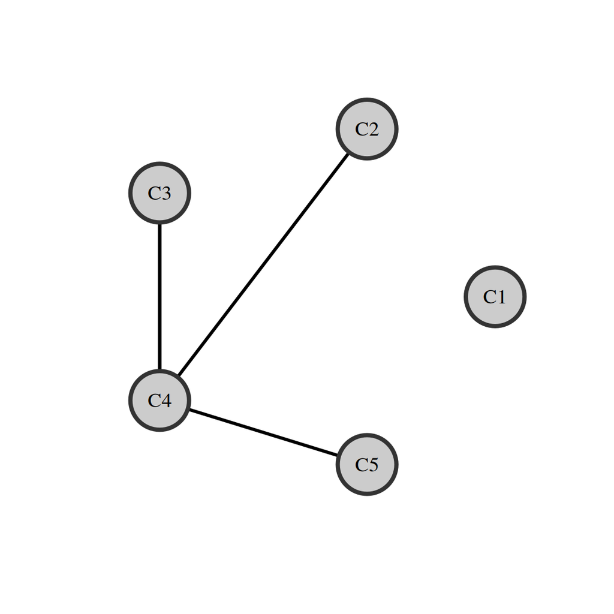

```r
plot_adj_as_network(
  layout = igraph::layout_in_circle,
  matrix = adj_matrix_ME$ME,
  min_edge = 0.5,
  node_label_size = 1.2,
  node_size = 35,
  edge_size = 5,
  node_frame_col = "grey20",
  node_fill_col = "grey80",
  vertex.frame.width = 4
)
```

# Save module identity

Obtain a list of genes in each module

```r
module_genes <- tidy_modules(
  merged_modules = merge[["colors"]],
  mapping_tbl = adj_matrix_ME$mapping_tbl,
  data = datExpr
)

# saveRDS(
#   module_genes,
#   here::here(
#     glue::glue(
#       "./data/tmp/{which.sample}_module_genes.RDS"
#     )
#   )
# )

# TO DO:
# Save the `dat_module_gene` as a database table in the respective database.
```

**NoteCompare GCN vs. ants**

```r
genes_across_species <- module_genes |>
  convert_id(
    from = "mouse",
    to = c("cflo", "drosophila")
  )

genes_across_species |>
  group_by(gene_name, module_identity) |>
  reframe(
    dmel = length(
      unique(
        na.omit(drosophila_ID)
      )
    ),
    cflo = length(
      unique(
        na.omit(cflo_ID)
      )
    )
  ) |>
  arrange(
    module_identity,
    desc(dmel),
    desc(cflo)
  ) |>
  mutate(
    across(
      c(dmel, cflo),
      ~ case_when(
        .x > 1 ~ "multi",
        .x == 1 ~ "single",
        .x == 0 ~ "x",
        .default = NA
      ) |>
        factor(
          levels = c("multi", "single", "x")
        )
    )
  ) |>
  group_by(module_identity, dmel, cflo) |>
  tally() |>
  arrange(module_identity, desc(n)) |>
  ungroup() |>
  DT::datatable(
    rownames = FALSE
  )
```

| module_identity | dmel | cflo | n |
| --- | --- | --- | --- |
| C1 | x | x | 1250 |
| C2 | x | x | 654 |
| C3 | x | x | 503 |
| C4 | x | x | 636 |
| C5 | x | x | 118 |

# Identify rhythmic modules

```r
db_rhy <- load_rhy_genes(
  sample = which.sample
)
###-###-###-###-###-###-###-###-
# Set your p-value of choice
# col_pval = "BH.Q"
col_pval = "default.pvalue"
# col_pval = "raw.pvalue"
###-###-###-###-###-###-###-###-
l_module_genes <- module_genes |>
  arrange(module_identity) |>
  group_split(module_identity) |>
  purrr::map(
    ~ .x |> pull(gene_name)
  ) |>
  setNames(unique(module_genes[["module_identity"]]))

l_rhy_genes <- db_rhy |>
  purrr::map(
    ~ .x |>
      filter(
        if_all(
          c(col_pval),
          ~ .x < 0.05
        )
      ) |>
      filter(
        ID %in% unlist(l_module_genes)
      ) |>
      pull(1) |>
      unique()
  ) |>
  purrr::compact()
```

## Comparison

> Modules vs. Rhythmic genes

```r
writeLines("#####################################################
How many genes are in each of my geneset of interest?
#####################################################")
```

```
#####################################################
How many genes are in each of my geneset of interest?
#####################################################
```

```r
## MAKE YOUR LIST OF GENES OF INTEREST ##

# LIST ONE - WGCNA modules
list1 <- l_module_genes
writeLines("List of interesting genes #1
----------------------------
Genes in each of the identified gene-clusters or modules")
```

```
List of interesting genes #1
----------------------------
Genes in each of the identified gene-clusters or modules
```

```r
sapply(list1, length)
```

```
  C1   C2   C3   C4   C5
1250  654  503  636  118
```

```r
## LIST TWO - rhythmic genes
list2 <- l_rhy_genes
writeLines("List of interesting genes #2
----------------------------
Rhythmic genes identified by different algorithms")
```

```
List of interesting genes #2
----------------------------
Rhythmic genes identified by different algorithms
```

```r
sapply(list2, length)
```

```
      ARS    empJTK GeneCycle       JTK    meta2d      RAIN
      110       289       164        73       115       267
```

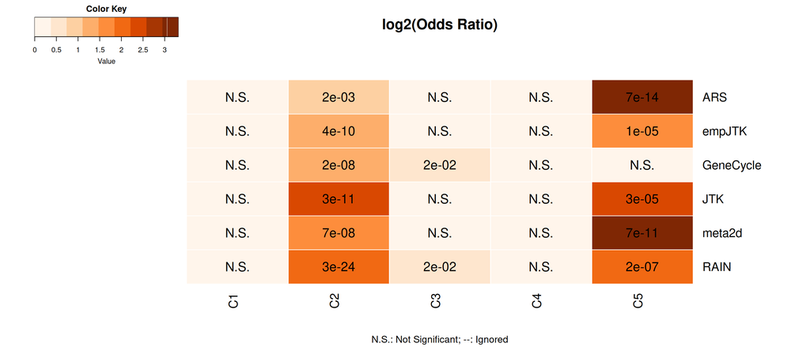

```r
## CHECK FOR OVERLAP
# define size of genome
size = length(unique(c(unlist(list1), unlist(list2))))
# make a GOM object
gom.1v2 <- GeneOverlap::newGOM(
  list2,
  list1,
  genome.size = size
)
# png(paste0(path_to_repo, "/results/figures/",
#            "02_pogo_GCN/",
#            sample.name[1],"_gom_1v2.png"),
#     width = 35, height = 15, units = "cm", res = 300)
GeneOverlap::drawHeatmap(
  gom.1v2,
  adj.p = TRUE,
  cutoff=0.05,
  what="odds.ratio",
  # what="Jaccard",
  log.scale = T,
  note.col = "black",
  grid.col = "Oranges"
)
```

```r
# trash <- dev.off()

 # writeLines("How many genes exactly are overlapping between the pairwise comparisons")
# getMatrix(gom.1v4, name = "intersection") %>% t()

writeLines("Visualizing the significant overlaps between your lists of interesting genes and the identified modules")
```

```
Visualizing the significant overlaps between your lists of interesting genes and the identified modules
```

# Network statistics

From [WGCNA-tutorial](https://horvath.genetics.ucla.edu/html/CoexpressionNetwork/Rpackages/WGCNA/Tutorials/Simulated-07-Membership.pdf)

## Intramodular connectivity

“We begin by calculating the intramodular connectivity for each gene. (In network literature, connectivity is often referred to as ”degree”.) The function intramodularConnectivity computes:

- the whole network connectivity *kTotal*,
- the within (intra)module connectivity *kWithin*,
- the extra-modular connectivity *kOut*=kTotal-kWithin, and
- the difference of the intra- and extra-modular connectivities *kDiff* = `kIn - kOut` = `2*kIN-kTotal`

```r
# From what I can tell, colorh1 in the tutorial refers to moduleColors
colorh1 <- merge$colors

# Calculate the connectivities of the genes
Alldegrees1 = WGCNA::intramodularConnectivity(
  adjMat = adj_matrix,
  colors = colorh1
) |>
  tibble::rownames_to_column("gene_name") |>
    mutate(
      across(
        matches("^k"),
        ~ round(.x, 2)
      )
    )
```

Plotting the mean (± 95% CI) connectivity of genes in different modules

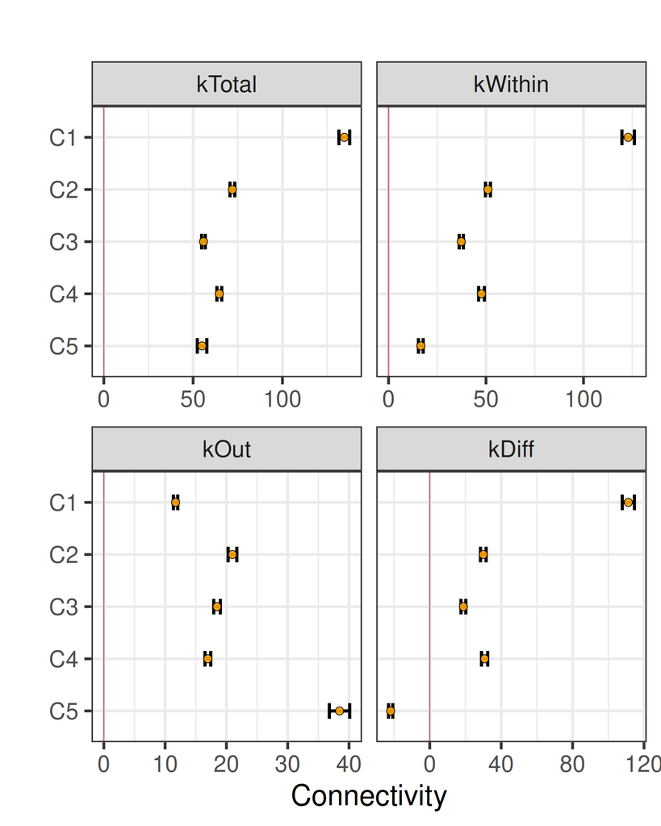

```r
pd <- position_dodge(0.1)

# which_var <- "kTotal"
which_var <- c("kTotal", "kWithin", "kOut", "kDiff")

Alldegrees1 |>
  # rownames_to_column("gene_name") %>%
  left_join(
    module_genes,
    join_by(gene_name)
  ) |>
  # PLOT FROM RAW DATA
  mutate(
    module_identity = factor(
      module_identity,
      levels = paste0(
        "C",
        sort(
          unique(module_genes$module_identity) |>
            stringr::str_replace("C", "") |>
            as.integer()
        )
      ) |> rev()
    )
  ) |>
  summarySE(
    measurevar = which_var,
    groupvars = "module_identity"
  ) |>
  mutate(
    type = factor(
      type,
      levels = which_var
    )
  ) |>
  # Plot
  ggplot(
    aes(
      y = module_identity,
      x = mean,
      group = interaction(module_identity, type)
    )
  ) +
  geom_vline(xintercept = 0, col = "maroon", alpha = 0.7) +
  labs(
    y = "",
    x = glue::glue(
      "Connectivity"
    ),
    title = ""
  ) +
  ## Add error bar here
  geom_errorbar(
    aes(xmin = mean-ci, xmax = mean+ci),
    width = 0.3,
    position=pd,
    lwd = 1.3,
    col="black",
    alpha = 1
  ) +
  # Add the points on top of the error bars
  geom_point(
    position = pd,
    size = 3,
    col = "black",
    fill = "orange",
    show.legend = F,
    pch = 21,
    alpha = 0.9
  ) +
  facet_wrap(
    ~ type,
    nrow = 2,
    scales = "free_x"
  ) +
  scale_x_continuous(
    n.breaks = 4
  ) +
  theme_bw(25) +
  # scale_color_manual(values=c("#F20505","#F5D736","#0FBF67")) +
  theme(
    legend.position = "none"
  )
```